# ACTG175 Continuous Analysis: Applied Operating Characteristics, Self-Contained

```r
suppressPackageStartupMessages({
  library(forestsearch)
  library(speff2trial)
  library(gt)
})

# ---------------------------------------------------------------------------
# Output location for this document's results:  <base>/<dirout>/
#   results_dir = NULL -> base is <qmd dir>/_payloads
#   dirout      = NULL -> the .qmd stem
# ---------------------------------------------------------------------------
results_dir <- NULL
# TASK_actg175_continuous_intervals_2026-09-07: committed payloads are read-only, so
# this render writes beside the committed OC payload rather than over it (the
# tracked HTML is refreshed per the directory's convention).
dirout      <- "analysis_actg175_continuous_oc_intervals"

# Everything below is computed in this document: the analysis, the anchored
# truths (the primary Q and its two supersets — the Q_variants knob, defined
# visibly in section 3 once the population frame exists), the candidate
# family, and the operating characteristics.  Nothing is read from disk.
# Re-render at other precisions via the YAML params (draws, n_workers,
# c2_ratio, seed); the archived companion
# analysis_actg175_continuous_oc_evaluation.qmd holds the deep fixed-c2 run.
q_rungs   <- c(0.01, 5, 10, 15, 20, 40, 60, 87 + 11 / 12)   # primary rungs; last = T_obs, gated below
q_shared  <- c(0.01, 5, 10, 20, 40, 87 + 11 / 12)           # rungs run for each Q superset, incl. its own sub-threshold null
c1_ladder <- sort(c(5, 10, 15, 20, 30, 40, 50, 60, 80, 100, 120, 87 + 11 / 12))
c2_vec    <- sort(unique(c(5, params$c2_ratio * c1_ladder)))

fmt  <- function(x, d = 3) formatC(x, format = "f", digits = d)
fmt0 <- function(x) formatC(x, format = "d")
pct  <- function(x, d = 1) paste0(fmt(100 * x, d), "%")
pm   <- function(x, s, d = 4) paste0(fmt(x, d), " ± ", fmt(s, d))
at   <- function(d, c1v, c2v) d[abs(d$c1 - c1v) < 1e-9 & abs(d$c2 - c2v) < 1e-9, ]
qlab <- function(x) fmt(x, ifelse(x %% 1 == 0, 1, 2))
t_doc <- proc.time()[["elapsed"]]
```

## 0.1 1. The data

The analysis frame is the compare-all document’s: ACTG175 arms 1 (ZDV+ddI) and 3 (ddI), outcome `y_decline` = CD4 decline from baseline to week 20 (adverse scale), six continuous and six binary candidate confounders.

```r
cont_vars <- c("age", "preanti", "wtkg", "karnof", "cd40", "cd80")
bin_vars  <- c("hemo", "homo", "drugs", "race", "gender", "symptom")
confounders.name <- c(cont_vars, bin_vars)

actg_df <- subset(speff2trial::ACTG175, arms %in% c(1L, 3L))
actg_df$id <- seq_len(nrow(actg_df))
actg_df$treat <- ifelse(actg_df$arms == 1L, 1L, 0L)
actg_df <- actg_df[!is.na(actg_df$cd420), ]
actg_df$y_decline <- actg_df$cd40 - actg_df$cd420
for (v in bin_vars) actg_df[[v]] <- as.factor(actg_df[[v]])

N <- nrow(actg_df)
stopifnot(N == 1083L)
cat("Analysis N =", N, "\n")
```

```
Analysis N = 1083
```

```r
# the unadjusted ITT mean difference — distinct from the covariate-adjusted
# GLM coefficient beta_treat the generator anchors to (section 3)
itt <- coef(summary(lm(y_decline ~ treat, data = actg_df)))["treat", ]
cat(sprintf("unadjusted ITT mean difference = %.3f (SE %.3f)\n",
            itt["Estimate"], itt["Std. Error"]))
```

```
unadjusted ITT mean difference = -27.591 (SE 7.889)
```

## 0.2 2. The analysis

The search whose operating characteristics this document evaluates is the fixed-family `maxeffCons` configuration — the compare-all document’s MR-anchor arm. Multiplier-resampling inference and the lasso/GRF front ends are mutually exclusive under `subgroup_method = "consistency"` (the family would be estimated from the same data the search runs on), so the inferential anchor runs with the front ends off, and the operating characteristics evaluated here are the operating characteristics of exactly that procedure.

```r
fs_anchor <- forestsearch(
  df.analysis      = actg_df,
  confounders.name = confounders.name,
  outcome.name     = "y_decline",
  treat.name       = "treat",
  id.name          = "id",
  outcome_type     = "continuous",
  effect_measure   = "MD",
  adverse_outcome  = TRUE,
  seedit           = params$seed,
  sg_focus         = "maxeffCons",
  selection_rule   = "neighborhood",
  consistency_method = "resample",
  effect.threshold       = 10,
  consistency.threshold  = 5,
  pconsistency.threshold = 0.90,
  use_twostage     = TRUE,
  conf.cont_jcuts  = list(age = 10, preanti = 10, wtkg = 10,
                          karnof = 10, cd40 = 10, cd80 = 10),
  cut_type         = "default",
  maxk             = 2L,
  n.min            = 60L,
  d0.min           = 10L,
  d1.min           = 10L,
  fs.splits        = 500L,
  use_lasso        = FALSE,
  use_grf          = FALSE,
  use_dina         = FALSE,
  is.RCT           = TRUE,
  parallel_args    = list(plan = "sequential"),
  details          = FALSE,
  quiet            = TRUE,
  # TASK_actg175_continuous_intervals_2026-09-07: the MR gate on this call --
  # ci_method = "field", the complement field and the re-selection frequencies
  # (add-only in the gate; the search is untouched).  mr_inference = TRUE and
  # draws = 5000L (the compare-all anchor's value) are the enabling settings.
  mr_inference     = TRUE,
  mr_inference_args = list(ci_method = "field", draws = 5000L,
                           include_complement = TRUE, field_complement = TRUE,
                           # TASK_actg175_continuous_field_s_2026-09-16: the studentized
                           # complement field (field-s), the package default, passed explicitly.
                           field_scale_complement = "selected",
                           return_reselection = TRUE)
)

H_def  <- paste(fs_anchor$sg.harm, collapse = " & ")
n_H    <- sum(fs_anchor$df.est$treat.recommend == 0L)
win    <- fs_anchor$grp.consistency$out_sg$result[1L, ]
T_obs  <- as.numeric(win$hr)      # MD scale: the hr column holds the MD
p_cons <- as.numeric(win$Pcons)
cat(sprintf("H-hat = %s;  n(H-hat) = %d;  T_obs = %.6f;  p.consistency = %.2f\n",
            H_def, n_H, T_obs, p_cons))
```

```
H-hat = {age <= 37} & !{cd40 <= 507};  n(H-hat) = 66;  T_obs = 87.916667;  p.consistency = 0.95
```

```r
# gates: the anchor must reproduce the compare-all / stage-0 result exactly
stopifnot(setequal(fs_anchor$sg.harm, c("{age <= 37}", "!{cd40 <= 507}")),
          n_H == 66L, abs(T_obs - (87 + 11 / 12)) < 5e-7)
q_rungs[length(q_rungs)] <- T_obs
q_shared[length(q_shared)] <- T_obs
c1_ladder[abs(c1_ladder - (87 + 11 / 12)) < 1e-9] <- T_obs
c2_vec <- sort(unique(c(5, params$c2_ratio * c1_ladder)))
```

The anchor: **Ĥ = `{age <= 37} & !{cd40 <= 507}`**, n(Ĥ) = 66 of 1083, fitted mean difference **T̂<sub>obs</sub> = 87.916667** CD4 units, consistency 0.95.

### 0.2.1 2.1 Post-selection intervals for the found subgroup and its complement

```r
g  <- fs_anchor$mr_inference
stopifnot(is.list(g), identical(g$ci_method, "field"),
          is.list(g$field), is.null(g$field$note),
          is.list(g$field$complement), is.null(g$field$complement$note),
          is.list(g$field$joint), is.null(g$field$joint$note),
          is.list(g$reselection), is.list(g$complement), !is.null(g$complement$debiased))
f  <- g$field; fc <- f$complement; jt <- f$joint; js <- f$joint_s; gc <- g$complement; rs <- g$reselection
z95 <- qnorm(0.95)
# Family labels are cut codes q<k>.<level>: k indexes fs_anchor$confounders.evaluated,
# level 1 = the cut holds, level 0 = its negation -- decoded here for display.
cuts <- fs_anchor$confounders.evaluated
lab_of <- function(code) paste(vapply(strsplit(code, " & ", fixed = TRUE)[[1]], function(t) {
  m <- regmatches(t, regexec("^q([0-9]+)\\.([01])$", t))[[1]]
  if (length(m) < 3L) return(t)
  paste0(if (m[3] == "0") "!" else "", "{", cuts[as.integer(m[2])], "}") }, character(1)),
  collapse = " & ")
# Gates inside the document: the gate's selected family member IS the found subgroup, its
# naive estimate IS T_obs, and the field's bounds are the stated inversions about beta-tilde.
stopifnot(setequal(strsplit(lab_of(g$selected_label), " & ", fixed = TRUE)[[1]], fs_anchor$sg.harm),
          g$n_selected == n_H, abs(g$naive$est - T_obs) < 1e-9,
          abs(f$lower_1s - (g$debiased$est - f$q95)) < 1e-9,
          abs(fc$upper_1s - (gc$debiased$est - fc$q05)) < 1e-9)
thr_H <- c(0, 10, 20, 30, 40); thr_Hc <- c(0, 10, 20, 30)
p_hat_H <- unname(rs$p_hat[g$selected_index])
top3    <- sort(rs$p_hat, decreasing = TRUE)[1:3]
# one-sided bounds on the oriented scale (harm block: lower; complement: upper)
lo1 <- c(naive = g$naive$est - z95 * g$debiased$se_wald, ij = g$debiased$lower_1s, field = f$lower_1s)
up1 <- c(naive = gc$naive$est + z95 * gc$debiased$se_wald, ij = gc$debiased$est + z95 * gc$debiased$se_ij,
         field = fc$upper_1s, field_s = fc$upper_1s_s)
fmt2 <- function(l, h) sprintf("(%.2f, %.2f)", l, h)
# the payload element (schema: TASK_actg175_continuous_intervals_2026-09-07)
iv <- list(
  scale = "oriented y_decline (positive = harm); raw cd4_change = sign flip",
  thresholds = list(H_lower = thr_H, Hc_upper = thr_Hc,
                    note = "simulation design's reference points (0/10/30/40 = no harm / consistency threshold / effect threshold / planted MD)"),
  settings = list(ci_method = g$ci_method, draws = g$settings$draws, multiplier = g$settings$multiplier,
                  reselection = g$settings$reselection, ij_residual = g$ij_residual, seed = params$seed,
                  field_R_out = f$R_out, field_R_in = f$R_in, n_family = g$n_family, n_selected = g$n_selected,
                  field_scale_complement = if (!is.null(fc$est2_s)) "selected" else "none"),
  H = list(naive = list(est = g$naive$est, lower = g$naive$lower, upper = g$naive$upper,
                        se_wald = g$debiased$se_wald, lower_1s = unname(lo1["naive"])),
           ij = list(est = g$debiased$est, lower = g$debiased$lower, upper = g$debiased$upper,
                     se_ij = g$debiased$se_ij, lower_1s = g$debiased$lower_1s,
                     selection_bias = g$selection_bias, fixed_bias = g$fixed_bias),
           field = list(est2 = f$est2, lower_1s = f$lower_1s, lower_2s = f$lower_2s, upper_2s = f$upper_2s,
                        lambda_sd = f$lambda_sd, lambda_mean = f$lambda_mean, q05 = f$q05, q95 = f$q95,
                        n_out_used = f$n_out_used, n_in_used_mean = f$n_in_used_mean,
                        timing_seconds = f$timing_seconds)),
  Hc = list(naive = list(est = gc$naive$est, lower = gc$naive$lower, upper = gc$naive$upper,
                         se_wald = gc$debiased$se_wald, upper_1s = unname(up1["naive"])),
            ij = list(est = gc$debiased$est, lower = gc$debiased$lower, upper = gc$debiased$upper,
                      se_ij = gc$debiased$se_ij, upper_1s = unname(up1["ij"])),
            field = list(est2 = fc$est2, upper_1s = fc$upper_1s, lower_1s = fc$lower_1s,
                         lower_2s = fc$lower_2s, upper_2s = fc$upper_2s, lambda_sd = fc$se_field,
                         lambda_mean = fc$lambda_mean, q05 = fc$q05, q95 = fc$q95,
                         n_out_used = fc$n_out_used, n_complement_fits = fc$n_complement_fits,
                         timing_seconds = fc$timing_seconds),
            # field-s (TASK_actg175_continuous_field_s_2026-09-16): the studentized complement field, the same names as Hc$field
            field_s = list(est2 = fc$est2_s, upper_1s = fc$upper_1s_s, lower_1s = fc$lower_1s_s,
                           lower_2s = fc$lower_2s_s, upper_2s = fc$upper_2s_s, lambda_sd = fc$se_field_s,
                           lambda_mean = fc$lambda_mean_s)),
  joint = list(gamma = jt$gamma, lower_H = jt$lower_H, upper_Hc = jt$upper_Hc, joint_prob = jt$joint_prob,
               bonf_lower_H = jt$bonf_lower_H, bonf_upper_Hc = jt$bonf_upper_Hc,
               bonf_joint_prob = jt$bonf_joint_prob, corr = jt$corr, n_joint_draws = jt$n_joint_draws),
  joint_s = list(gamma = js$gamma, lower_H = js$lower_H, upper_Hc = js$upper_Hc, joint_prob = js$joint_prob,
                 bonf_lower_H = js$bonf_lower_H, bonf_upper_Hc = js$bonf_upper_Hc,
                 bonf_joint_prob = js$bonf_joint_prob, corr = js$corr, n_joint_draws = js$n_joint_draws),
  reselection = list(p_hat_H = p_hat_H, selection_rate = g$selection_rate,
                     top3_labels = vapply(names(top3), lab_of, character(1)), top3_codes = names(top3),
                     top3_p_hat = unname(top3)),
  timing_seconds = list(multiplier_stage = g$timing_seconds, field = f$timing_seconds,
                        complement_field = fc$timing_seconds))
```

```r
tab1 <- data.frame(
  Method = c("Naive", "MR (IJ two-term)", "MR (field)"),
  `Point est. (oriented)` = c(sprintf("%.2f", g$naive$est), sprintf("%.2f (β̃)", g$debiased$est),
                              sprintf("%.2f (est₂); β̃ %.2f", f$est2, g$debiased$est)),
  `SE` = c(sprintf("%.2f (robust)", g$debiased$se_wald), sprintf("%.2f (IJ)", g$debiased$se_ij),
           sprintf("%.2f (λ-SD)", f$lambda_sd)),
  `Two-sided 95% (oriented)` = c(fmt2(g$naive$lower, g$naive$upper), fmt2(g$debiased$lower, g$debiased$upper),
                                 fmt2(f$lower_2s, f$upper_2s)),
  `One-sided 95% LOWER (oriented)` = sprintf("%.2f", lo1),
  `Point est. (cd4_change)` = sprintf("%.2f", -c(g$naive$est, g$debiased$est, f$est2)),
  `Two-sided 95% (cd4_change)` = c(fmt2(-g$naive$upper, -g$naive$lower), fmt2(-g$debiased$upper, -g$debiased$lower),
                                   fmt2(-f$upper_2s, -f$lower_2s)),
  `One-sided 95% bound (cd4_change): change ≤` = sprintf("%.2f", -lo1),
  check.names = FALSE)
gt(tab1) |>
  tab_header(title = "Table 1 — Ĥ: interval constructions for the found subgroup",
             subtitle = sprintf("Ĥ = %s, n = %d of %d; oriented = y_decline (positive = harm); cd4_change = sign flip",
                                H_def, n_H, N)) |>
  tab_footnote(footnote = paste(
    "One-sided conventions: naive est − 1.645·SE(robust); MR (IJ) the gate's stored selection-adjusted lower_1s (β̃ − 1.645·SE_IJ);",
    "MR (field) β̃ − q₀.₉₅(Λ*), built on the de-biased estimate β̃, not on est₂ (est₂ = β̃ − mean Λ*). The field's SE column is the Λ*-SD.",
    "On the cd4_change scale the harm lower bound L becomes an upper bound on the change: change ≤ −L."))
```

Table 1 — Ĥ: interval constructions for the found subgroup

Ĥ = {age <= 37} & !{cd40 <= 507}, n = 66 of 1083; oriented = y_decline (positive = harm); cd4_change = sign flip

| Method | Point est. (oriented) | SE | Two-sided 95% (oriented) | One-sided 95% LOWER (oriented) | Point est. (cd4_change) | Two-sided 95% (cd4_change) | One-sided 95% bound (cd4_change): change ≤ |
| --- | --- | --- | --- | --- | --- | --- | --- |
| Naive | 87.92 | 42.66 (robust) | (4.31, 171.53) | 17.75 | -87.92 | (-171.53, -4.31) | -17.75 |
| MR (IJ two-term) | 33.61 (β̃) | 53.91 (IJ) | (-72.04, 139.27) | -55.05 | -33.61 | (-139.27, 72.04) | 55.05 |
| MR (field) | 27.26 (est₂); β̃ 33.61 | 38.79 (λ-SD) | (-56.44, 94.20) | -43.80 | -27.26 | (-94.20, 56.44) | 43.80 |

One-sided conventions: naive est − 1.645·SE(robust); MR (IJ) the gate's stored selection-adjusted lower_1s (β̃ − 1.645·SE_IJ); MR (field) β̃ − q₀.₉₅(Λ*), built on the de-biased estimate β̃, not on est₂ (est₂ = β̃ − mean Λ*). The field's SE column is the Λ*-SD. On the cd4_change scale the harm lower bound L becomes an upper bound on the change: change ≤ −L.

```r
cat(sprintf(paste0(
  "Retained-optimism spread on the oriented scale: naive %.2f → MR (IJ) %.2f → MR (field) est₂ %.2f, ",
  "i.e. the corrections remove %.2f (IJ) and %.2f (field) CD4 cells/mm³ of the naive estimate ",
  "(selection term %.2f, fixed term %.2f in the two-term correction).\n\n"),
  g$naive$est, g$debiased$est, f$est2, g$naive$est - g$debiased$est, g$naive$est - f$est2,
  g$selection_bias, g$fixed_bias))
```

Retained-optimism spread on the oriented scale: naive 87.92 → MR (IJ) 33.61 → MR (field) est₂ 27.26, i.e. the corrections remove 54.30 (IJ) and 60.66 (field) CD4 cells/mm³ of the naive estimate (selection term 52.71, fixed term 1.59 in the two-term correction).

```r
tab2 <- data.frame(
  Method = c("Naive", "MR (IJ two-term)", "MR (field, unstudentized)", "MR (field-s)"),
  `Point est. (oriented)` = c(sprintf("%.2f", gc$naive$est), sprintf("%.2f (β̃ᶜ)", gc$debiased$est),
                              sprintf("%.2f (est₂); β̃ᶜ %.2f", fc$est2, gc$debiased$est),
                              sprintf("%.2f (est₂ˢ); β̃ᶜ %.2f", fc$est2_s, gc$debiased$est)),
  `SE` = c(sprintf("%.2f (robust)", gc$debiased$se_wald), sprintf("%.2f (IJ)", gc$debiased$se_ij),
           sprintf("%.2f (λ-SDᶜ)", fc$se_field), sprintf("%.2f (λ-SDᶜ, studentized)", fc$se_field_s)),
  `Two-sided 95% (oriented)` = c(fmt2(gc$naive$lower, gc$naive$upper), fmt2(gc$debiased$lower, gc$debiased$upper),
                                 fmt2(fc$lower_2s, fc$upper_2s), fmt2(fc$lower_2s_s, fc$upper_2s_s)),
  `One-sided 95% UPPER (oriented)` = sprintf("%.2f", up1),
  `Point est. (cd4_change)` = sprintf("%.2f", -c(gc$naive$est, gc$debiased$est, fc$est2, fc$est2_s)),
  `Two-sided 95% (cd4_change)` = c(fmt2(-gc$naive$upper, -gc$naive$lower), fmt2(-gc$debiased$upper, -gc$debiased$lower),
                                   fmt2(-fc$upper_2s, -fc$lower_2s), fmt2(-fc$upper_2s_s, -fc$lower_2s_s)),
  `One-sided 95% bound (cd4_change): change ≥` = sprintf("%.2f", -up1),
  check.names = FALSE)
gt(tab2) |>
  tab_header(title = "Table 2 — Ĥᶜ: interval constructions for the complement (benefit claim)",
             subtitle = sprintf("Ĥᶜ: n = %d; the one-sided UPPER bound is the exposed limit for a benefit claim (\"harm at most U\" = \"benefit at least −U\")",
                                N - n_H)) |>
  tab_footnote(footnote = sprintf(paste(
    "One-sided conventions: naive est + 1.645·SE(robust); MR (IJ) β̃ᶜ + 1.645·SE_IJ; MR (field) the gate's stored upper_1s = β̃ᶜ − q₀.₀₅(Λ*ᶜ);",
    "MR (field-s) the studentized complement field's upper_1s_s = β̃ᶜ − q₀.₀₅(Λ*ᶜₛ), each reading rescaled to the selected complement's influence-norm scale (field_scale_complement = \"selected\", the package default; the evaluated complement product).",
    "Regime diagnostic: λ-SDᶜ / naive SE = %.3f unstudentized, %.3f studentized (the IJ SE / naive SE = %.3f)."),
    fc$se_field / gc$debiased$se_wald, fc$se_field_s / gc$debiased$se_wald, gc$debiased$se_ij / gc$debiased$se_wald))
```

Table 2 — Ĥᶜ: interval constructions for the complement (benefit claim)

Ĥᶜ: n = 1017; the one-sided UPPER bound is the exposed limit for a benefit claim ("harm at most U" = "benefit at least −U")

| Method | Point est. (oriented) | SE | Two-sided 95% (oriented) | One-sided 95% UPPER (oriented) | Point est. (cd4_change) | Two-sided 95% (cd4_change) | One-sided 95% bound (cd4_change): change ≥ |
| --- | --- | --- | --- | --- | --- | --- | --- |
| Naive | -36.54 | 7.83 (robust) | (-51.89, -21.19) | -23.66 | 36.54 | (21.19, 51.89) | 23.66 |
| MR (IJ two-term) | -33.62 (β̃ᶜ) | 15.12 (IJ) | (-63.25, -3.98) | -8.75 | 33.62 | (3.98, 63.25) | 8.75 |
| MR (field, unstudentized) | -31.96 (est₂); β̃ᶜ -33.62 | 8.07 (λ-SDᶜ) | (-46.81, -16.35) | -18.55 | 31.96 | (16.35, 46.81) | 18.55 |
| MR (field-s) | -31.97 (est₂ˢ); β̃ᶜ -33.62 | 7.96 (λ-SDᶜ, studentized) | (-46.83, -16.42) | -18.90 | 31.97 | (16.42, 46.83) | 18.90 |

One-sided conventions: naive est + 1.645·SE(robust); MR (IJ) β̃ᶜ + 1.645·SE_IJ; MR (field) the gate's stored upper_1s = β̃ᶜ − q₀.₀₅(Λ*ᶜ); MR (field-s) the studentized complement field's upper_1s_s = β̃ᶜ − q₀.₀₅(Λ*ᶜₛ), each reading rescaled to the selected complement's influence-norm scale (field_scale_complement = "selected", the package default; the evaluated complement product). Regime diagnostic: λ-SDᶜ / naive SE = 1.030 unstudentized, 1.016 studentized (the IJ SE / naive SE = 1.931).

```r
tab3 <- data.frame(
  Pair = c("Separate one-sided 95% field bounds (unstudentized)", "Bonferroni (γ = 0.025 each) (unstudentized)",
           sprintf("Calibrated from field$joint (γ = %.3f) (unstudentized)", jt$gamma),
           "Bonferroni (γ = 0.025 each), field-s", sprintf("Calibrated from field$joint_s (γ = %.3f), field-s", js$gamma)),
  `Ĥ lower (oriented)` = sprintf("%.2f", c(f$lower_1s, jt$bonf_lower_H, jt$lower_H, js$bonf_lower_H, js$lower_H)),
  `Ĥᶜ upper (oriented)` = sprintf("%.2f", c(fc$upper_1s, jt$bonf_upper_Hc, jt$upper_Hc, js$bonf_upper_Hc, js$upper_Hc)),
  `Ĥ: change ≤ (cd4_change)` = sprintf("%.2f", -c(f$lower_1s, jt$bonf_lower_H, jt$lower_H, js$bonf_lower_H, js$lower_H)),
  `Ĥᶜ: change ≥ (cd4_change)` = sprintf("%.2f", -c(fc$upper_1s, jt$bonf_upper_Hc, jt$upper_Hc, js$bonf_upper_Hc, js$upper_Hc)),
  `Joint prob. on the aligned draws` = c("< 0.95 by construction", sprintf("%.3f", jt$bonf_joint_prob),
                                         sprintf("%.3f", jt$joint_prob), sprintf("%.3f", js$bonf_joint_prob),
                                         sprintf("%.3f", js$joint_prob)),
  check.names = FALSE)
gt(tab3) |>
  tab_header(title = "Table 3 — the joint pair (Ĥ lower bound, Ĥᶜ upper bound)",
             subtitle = sprintf("unstudentized: γ = %.3f on the 0.025–0.050 grid, corr(Λ*, Λ*ᶜ) = %+.3f over %d aligned draws; field-s: γ = %.3f, corr = %+.3f over %d",
                                jt$gamma, jt$corr, jt$n_joint_draws, js$gamma, js$corr, js$n_joint_draws))
```

Table 3 — the joint pair (Ĥ lower bound, Ĥᶜ upper bound)

unstudentized: γ = 0.025 on the 0.025–0.050 grid, corr(Λ*, Λ*ᶜ) = -0.019 over 983 aligned draws; field-s: γ = 0.025, corr = -0.017 over 983

| Pair | Ĥ lower (oriented) | Ĥᶜ upper (oriented) | Ĥ: change ≤ (cd4_change) | Ĥᶜ: change ≥ (cd4_change) | Joint prob. on the aligned draws |
| --- | --- | --- | --- | --- | --- |
| Separate one-sided 95% field bounds (unstudentized) | -43.80 | -18.55 | 43.80 | 18.55 | < 0.95 by construction |
| Bonferroni (γ = 0.025 each) (unstudentized) | -56.44 | -16.35 | 56.44 | 16.35 | 0.949 |
| Calibrated from field$joint (γ = 0.025) (unstudentized) | -56.44 | -16.35 | 56.44 | 16.35 | 0.949 |
| Bonferroni (γ = 0.025 each), field-s | -56.44 | -16.42 | 56.44 | 16.42 | 0.949 |
| Calibrated from field$joint_s (γ = 0.025), field-s | -56.44 | -16.42 | 56.44 | 16.42 | 0.949 |

```r
tab4 <- data.frame(
  Quantity = c(sprintf("p̂(Ĥ)  [selected: %s]", lab_of(g$selected_label)),
               sprintf("Top re-selected: %s", lab_of(names(top3)[1])),
               sprintf("2nd: %s", lab_of(names(top3)[2])),
               sprintf("3rd: %s", lab_of(names(top3)[3])),
               "Selection rate (draws with a winner); family size",
               "Field Λ*-mean (second-order term, oriented)",
               "Field λ-SD vs IJ SE; vs naive SE (Ĥ)",
               "Field draw usage (outer used / R_out; mean inner / R_in)",
               "Complement fits per gate call; λ-SDᶜ vs naive SE (Ĥᶜ)"),
  Value = c(sprintf("%.3f", p_hat_H), sprintf("%.3f", top3[1]), sprintf("%.3f", top3[2]), sprintf("%.3f", top3[3]),
            sprintf("%.3f; %d candidates", g$selection_rate, g$n_family),
            sprintf("%+.3f", f$lambda_mean),
            sprintf("%.2f / %.2f = %.2f; %.2f / %.2f = %.2f", f$lambda_sd, g$debiased$se_ij, f$lambda_sd / g$debiased$se_ij,
                    f$lambda_sd, g$debiased$se_wald, f$lambda_sd / g$debiased$se_wald),
            sprintf("%d / %d; %.0f / %d", f$n_out_used, f$R_out, f$n_in_used_mean, f$R_in),
            sprintf("%d; %.2f / %.2f = %.3f", fc$n_complement_fits, fc$se_field, gc$debiased$se_wald,
                    fc$se_field / gc$debiased$se_wald)),
  check.names = FALSE)
gt(tab4) |> tab_header(title = "Re-selection and field diagnostics",
                       subtitle = "p̂ near 1 = settled selection; below ~0.5 = tie regime (the second-order field correction matters most)")
```

Re-selection and field diagnostics

p̂ near 1 = settled selection; below ~0.5 = tie regime (the second-order field correction matters most)

| Quantity | Value |
| --- | --- |
| p̂(Ĥ) [selected: {age <= 37} & !{cd40 <= 507}] | 0.087 |
| Top re-selected: {age <= 35} & !{cd40 <= 507} | 0.218 |
| 2nd: !{wtkg <= 73} & !{cd40 <= 507} | 0.169 |
| 3rd: {age <= 37} & !{cd40 <= 507} | 0.087 |
| Selection rate (draws with a winner); family size | 0.972; 4935 candidates |
| Field Λ*-mean (second-order term, oriented) | +6.355 |
| Field λ-SD vs IJ SE; vs naive SE (Ĥ) | 38.79 / 53.91 = 0.72; 38.79 / 42.66 = 0.91 |
| Field draw usage (outer used / R_out; mean inner / R_in) | 983 / 1000; 499 / 500 |
| Complement fits per gate call; λ-SDᶜ vs naive SE (Ĥᶜ) | 761; 8.07 / 7.83 = 1.030 |

**NoteReading the intervals (generated from the numbers above at render time)**

```r
U <- fc$upper_1s_s; U_u <- fc$upper_1s; L <- f$lower_1s   # field-s is the evaluated complement bound; U_u the unstudentized before/after
sup_Hc <- thr_Hc[U <= thr_Hc]; not_Hc <- thr_Hc[U > thr_Hc]
sup_H  <- thr_H[L >= thr_H];  not_H  <- thr_H[L < thr_H]
say <- function(v) if (length(v)) paste(v, collapse = ", ") else "none"
cat(sprintf(paste0(
  "- **Complement first (the benefit claim).** The field-s one-sided 95%% upper bound on Ĥᶜ is %.2f on the oriented scale ",
  "(a CD4 change of at least %.2f on the raw scale). Against the reading thresholds, \"harm at most τ on Ĥᶜ\" is supported for τ = %s ",
  "and not supported for τ = %s. The unstudentized field's upper bound, the paired before-and-after, is %.2f (change ≥ %.2f). ",
  "Comparators: MR (IJ) upper %.2f (change ≥ %.2f), naive upper %.2f (change ≥ %.2f).\n"),
  U, -U, say(sup_Hc), say(not_Hc), U_u, -U_u, up1["ij"], -up1["ij"], up1["naive"], -up1["naive"]))
```

- **Complement first (the benefit claim).** The field-s one-sided 95% upper bound on Ĥᶜ is -18.90 on the oriented scale (a CD4 change of at least 18.90 on the raw scale). Against the reading thresholds, “harm at most τ on Ĥᶜ” is supported for τ = 0, 10, 20, 30 and not supported for τ = none. The unstudentized field’s upper bound, the paired before-and-after, is -18.55 (change ≥ 18.55). Comparators: MR (IJ) upper -8.75 (change ≥ 8.75), naive upper -23.66 (change ≥ 23.66).

```r
cat(sprintf(paste0(
  "- **Ĥ (the harm claim).** The field's one-sided 95%% lower bound is %.2f on the oriented scale (a CD4 change of at most %.2f). ",
  "\"Harm at least τ on Ĥ\" is supported for τ = %s and not supported for τ = %s. The naive lower bound is %.2f.\n"),
  L, -L, say(sup_H), say(not_H), lo1["naive"]))
```

- **Ĥ (the harm claim).** The field’s one-sided 95% lower bound is -43.80 on the oriented scale (a CD4 change of at most 43.80). “Harm at least τ on Ĥ” is supported for τ = none and not supported for τ = 0, 10, 20, 30, 40. The naive lower bound is 17.75.

```r
cat(sprintf(paste0(
  "- **MR (IJ two-term) as the conservative reference:** lower bound on Ĥ %.2f (SE %.2f, %.2f× the naive SE), upper bound on Ĥᶜ %.2f ",
  "(SE %.2f, %.2f× the naive SE); its bounds sit %s the field's on both blocks.\n"),
  lo1["ij"], g$debiased$se_ij, g$debiased$se_ij / g$debiased$se_wald, up1["ij"], gc$debiased$se_ij,
  gc$debiased$se_ij / gc$debiased$se_wald,
  if (lo1["ij"] <= L && up1["ij"] >= U) "outside" else "not uniformly outside"))
```

- **MR (IJ two-term) as the conservative reference:** lower bound on Ĥ -55.05 (SE 53.91, 1.26× the naive SE), upper bound on Ĥᶜ -8.75 (SE 15.12, 1.93× the naive SE); its bounds sit outside the field’s on both blocks.

```r
cat(sprintf(paste0(
  "- **A claim on both subgroups** uses the field-s Bonferroni pair (Ĥ lower %.2f, Ĥᶜ upper %.2f; on the cd4_change scale: Ĥ change ≤ %.2f, ",
  "Ĥᶜ change ≥ %.2f): \"harm at least τ on Ĥ\" is supported for τ = %s and \"harm at most τ on Ĥᶜ\" for τ = %s; ",
  "the calibrated field-s pair at γ = %.3f %s it (corr(Λ*, Λ*ᶜₛ) = %+.3f).\n"),
  js$bonf_lower_H, js$bonf_upper_Hc, -js$bonf_lower_H, -js$bonf_upper_Hc,
  say(thr_H[js$bonf_lower_H >= thr_H]), say(thr_Hc[js$bonf_upper_Hc <= thr_Hc]), js$gamma,
  if (abs(js$gamma - 0.025) < 1e-9) "coincides with" else "is tighter than", js$corr))
```

- **A claim on both subgroups** uses the field-s Bonferroni pair (Ĥ lower -56.44, Ĥᶜ upper -16.42; on the cd4_change scale: Ĥ change ≤ 56.44, Ĥᶜ change ≥ 16.42): “harm at least τ on Ĥ” is supported for τ = none and “harm at most τ on Ĥᶜ” for τ = 0, 10, 20, 30; the calibrated field-s pair at γ = 0.025 coincides with it (corr(Λ*, Λ*ᶜₛ) = -0.017).

```r
cat(sprintf(paste0(
  "- **The price of selection:** on Ĥ the adjusted one-sided lower bounds span %.2f (field) to %.2f (IJ) against the naive %.2f; ",
  "on Ĥᶜ the adjusted upper bounds span %.2f (field-s) to %.2f (IJ) against the naive %.2f. The point estimates move from the naive %.2f ",
  "to %.2f (IJ) and %.2f (field est₂) on Ĥ.\n"),
  L, lo1["ij"], lo1["naive"], U, up1["ij"], up1["naive"], g$naive$est, g$debiased$est, f$est2))
```

- **The price of selection:** on Ĥ the adjusted one-sided lower bounds span -43.80 (field) to -55.05 (IJ) against the naive 17.75; on Ĥᶜ the adjusted upper bounds span -18.90 (field-s) to -8.75 (IJ) against the naive -23.66. The point estimates move from the naive 87.92 to 33.61 (IJ) and 27.26 (field est₂) on Ĥ.

```r
cat(sprintf(paste0(
  "- **Regime:** p̂(Ĥ) = %.3f — the selected subgroup wins the re-selection on %.1f%% of multiplier draws, %s. ",
  "λ-SDᶜ / naive SE = %.3f on the complement.\n"),
  p_hat_H, 100 * p_hat_H,
  if (p_hat_H >= 0.5) "a settled selection" else "the tie regime (family labels with near-identical membership compete; the simulation campaign mdf1 found the field's one-sided bounds at nominal in exactly this regime on this DGM family)",
  fc$se_field / gc$debiased$se_wald))
```

- **Regime:** p̂(Ĥ) = 0.087 — the selected subgroup wins the re-selection on 8.7% of multiplier draws, the tie regime (family labels with near-identical membership compete; the simulation campaign mdf1 found the field’s one-sided bounds at nominal in exactly this regime on this DGM family). λ-SDᶜ / naive SE = 1.030 on the complement.

```r
cat(sprintf(paste0(
  "\nProvenance: forestsearch %s; ci_method = %s, %d multiplier draws (%s), field R_out/R_in = %d/%d, ij_residual = %s, seed = %d; ",
  "gate wall %.1f s (multiplier stage %.1f s, field %.1f s, complement field %.1f s).\n"),
  as.character(utils::packageVersion("forestsearch")), g$ci_method, g$settings$draws, g$settings$multiplier,
  f$R_out, f$R_in, g$ij_residual, params$seed,
  g$timing_seconds + f$timing_seconds + fc$timing_seconds, g$timing_seconds, f$timing_seconds, fc$timing_seconds))
```

Provenance: forestsearch 0.3.5; ci_method = field, 5000 multiplier draws (poisson), field R_out/R_in = 1000/500, ij_residual = two_term, seed = 8316951; gate wall 46.7 s (multiplier stage 20.5 s, field 19.4 s, complement field 6.8 s).

No claim is made beyond these numbers; the thresholds are the simulation design’s reference points and may be replaced.

## 0.3 3. The anchored truth, and the Q knob

Truths are anchored to the analysis data by a two-point mixture stylization: the super-population (draws of the covariate rows themselves) has exactly two treatment-effect values — the fitted background effect on Q<sup>c</sup> and a planted effect q on Q — with the baseline outcome surface and residual scale taken from the baseline GLM fit to the analysis data. Nothing else about the joint covariate law is modeled. The primary Q is Ĥ carried into the generator by its clause mapping (`age = 37`; `cd40 = list(type = "greater", value = 507)`), and on the identity link `k_inter(q) = q − beta_treat` — which is Q-independent, since the within-Q effect is `beta_treat + k_inter` for any Q.

```r
fml_base <- as.formula(paste("y_decline ~ treat +",
                             paste(c(bin_vars, cont_vars), collapse = " + ")))
beta_treat <- unname(coef(glm(fml_base, data = actg_df,
                              family = gaussian()))["treat"])
cat(sprintf("baseline GLM beta_treat = %.6f;  k_inter(q) = q + %.6f\n",
            beta_treat, -beta_treat))
```

```
baseline GLM beta_treat = -26.978725;  k_inter(q) = q + 26.978725
```

```r
Q_primary <- list(age = 37, cd40 = list(type = "greater", value = 507))

dgm_at <- function(q, cuts) generate_glm_dgm(
  data            = actg_df,
  factor_vars     = bin_vars,
  continuous_vars = cont_vars,
  outcome_var     = "y_decline",
  treatment_var   = "treat",
  outcome_type    = "continuous",
  effect_measure  = "MD",
  subgroup_vars   = c("age", "cd40"),
  subgroup_cuts   = cuts,
  model           = "alt",
  k_treat         = 1,
  k_inter         = q - beta_treat,
  adverse_outcome = TRUE,   # inert for a continuous outcome: the negation branch is binary-only
  n_super         = 5000L,
  seed            = params$seed,
  verbose         = FALSE
)

dgm_top <- dgm_at(T_obs, Q_primary)
print(fs_dgm_scale(dgm_top))
```

```
Difference-in-means sampling scale
  outcome_type   : continuous (MD)
  allocation     : 1:1  (p = 0.5000)
  sigma          : 122.810629   (sigma^2 = 15082.4505)
  n_super        : 5000

  region  n_g    P_g    V_mu0    C_mu0_tau        V_tau  bracket    V_eff
1      Q  317 0.0634 1602.372 1.538110e-13 2.688398e-28 16684.82 66739.29
2     Qc 4683 0.9366 1523.395 5.212604e-14 2.204323e-28 16605.85 66423.38
3      S 5000 1.0000 1939.403 5.676045e+02 7.838783e+02 17981.40 71925.59
```

**The knob.** The true subgroup is a named list of cutpoint sets — this list is the document’s knob. The primary is Ĥ’s exact clauses; the two supersets keep the same factors with more permissive thresholds, chosen from the family’s own population cut grid (the J = 10 quantile cuts the enumeration uses) to land nearest 2× and 3× Ĥ’s prevalence. The truth is a modeling choice: the primary plants the found rule, the variants ask what the same analysis means if the truly harmed population is broader than the sharp rule the search returned.

```r
ds   <- dgm_top$df_super
P_of <- function(cuts) mean(ds$age <= cuts$age & ds$cd40 > cuts$cd40$value)
P0   <- P_of(Q_primary)

# the family's population cut grid: quantile cuts at k/(J+1), k = 1..J = 10
age_grid  <- unname(quantile(ds$age,  (1:10) / 11))
cd40_grid <- unname(quantile(ds$cd40, (1:10) / 11))
cand <- expand.grid(a = age_grid[age_grid > 37], c = cd40_grid[cd40_grid < 507])
cand$P <- mapply(function(a, c) mean(ds$age <= a & ds$cd40 > c), cand$a, cand$c)
pick <- function(target, ok) { d <- cand[ok, ]; d[which.min(abs(d$P - target)), ] }
w <- pick(2 * P0, rep(TRUE, nrow(cand)))
b <- pick(3 * P0, cand$a >= w$a & cand$c <= w$c & cand$P > w$P)

Q_variants <- list(
  primary = Q_primary,
  wider   = list(age = w$a, cd40 = list(type = "greater", value = w$c)),
  broad   = list(age = b$a, cd40 = list(type = "greater", value = b$c)))
prev <- sapply(Q_variants, P_of)
for (v in names(Q_variants)) cat(sprintf(
  "%-8s age <= %-6s & cd40 > %-6s  P = %.4f  (%.2fx primary)\n", v,
  format(Q_variants[[v]]$age), format(Q_variants[[v]]$cd40$value),
  prev[v], prev[v] / P0))
```

```
primary  age <= 37     & cd40 > 507     P = 0.0634  (1.00x primary)
wider    age <= 39     & cd40 > 449     P = 0.1240  (1.96x primary)
broad    age <= 39     & cd40 > 412     P = 0.1906  (3.01x primary)
```

```r
# gate: strict nesting Q_primary < Q_wider < Q_broad on df_super
memb3 <- sapply(Q_variants, function(cu) ds$age <= cu$age & ds$cd40 > cu$cd40$value)
stopifnot(all(memb3[, 1] <= memb3[, 2]), all(memb3[, 2] <= memb3[, 3]),
          sum(memb3[, 1]) < sum(memb3[, 2]), sum(memb3[, 2]) < sum(memb3[, 3]))
```

## 0.4 4. The family

The evaluation family is the analyst’s own discovery grid at n = 1083, enumerated on the super-population from the same covariates, quantile cuts, and floors the search uses. It is kept pure — Q is not forced in.

```r
fs_args <- list(
  confounders.name = confounders.name,
  conf.cont_jcuts  = list(age = 10, preanti = 10, wtkg = 10,
                          karnof = 10, cd40 = 10, cd80 = 10),
  cut_type         = "default",
  cont.cutoff      = 4L,
  maxk             = 2L,
  n.min            = 60L
)
fam <- fs_oc_family_enumerate(dgm_top, fs_args, n = N, max_M = 10000L,
                              verbose = FALSE)
print(fam)
```

```
Population-enumerated candidate family (fs_oc_family)
  M            : 4508 candidates (from 108 cut columns, maxk = 2)
  n            : 1083
  floors       : n.min = 60 (Pg >= 0.0554), minp = 0.025, rmin = 5
  prevalence   : 0.0556 to 0.9196
  P(Q)         : 0.0634;  purity range 0.000 to 0.997
  dropped      : empty 255, minp 0, rmin 215, size 707, duplicate 201
```

```r
stopifnot(fam$M == 4508L, fam$orientation$s == 1)

# Q's representability: nearest member by Jaccard against H-hat on the
# super-population rows
H_super <- as.logical(dgm_top$df_super$flag_harm)
inter   <- colMeans(fam$memb & H_super)
jac     <- inter / (fam$Pg + mean(H_super) - inter)
i_near  <- which.max(jac)
purity_near <- inter[i_near] / fam$Pg[i_near]
cat(sprintf("nearest member: %s  (purity %.4f, Jaccard %.4f)\n",
            fam$lab[i_near], purity_near, jac[i_near]))
```

```
nearest member: age <= 37 & cd40 > 506  (purity 0.9969, Jaccard 0.9969)
```

Ĥ’s `cd40` threshold (507) lies just off the population quantile grid, so no family member is identical to Ĥ; the nearest member (`age <= 37 & cd40 > 506`) matches it with purity 0.9969. This is a feature of the evaluation, not a defect: the search is scored on the family it actually searches.

## 0.5 5. The fundamental call

This one call is the wrapper; everything below is this call swept over truths and thresholds. It is evaluated at the analyst’s screening floor c1 = 10 with the scaled consistency floor c2 = 0.8·c1 = 8, on the top-rung family (planted q = T̂<sub>obs</sub>).

```r
pred <- fs_oc_predict(family = fam, n = N,
                      c1 = 10, c2 = params$c2_ratio * 10,
                      consistency_method = "resample", pconsistency = 0.90,
                      draws = params$draws, seed = params$seed)
print(pred)
```

```
Predicted operating characteristics (fs_oc_predict)
  family      : M = 4508;  n = 1083;  gate = resample (c1 = 10, c2 = 8, pcons = 0.9);  draws = 20,000;  seed = 8316951
  detection rate (DETECTED share)            : 0.952  (MC SE 0.0015)
  E[|Hhat|] given detection                  : 67.2
  E[sens] / E[spec] / E[PPV] / E[NPV]        : 0.779 / 0.987 / 0.811 / 0.985
  E[beta(Hhat)] oriented                     : 66.16
  E[naive - beta(Hhat)]                      : 35.03
  selection mass on rules with mean < c1     : 0.117
  top selections (P_selected, sel | det):
    age <= 33 & cd40 > 506                   0.249  0.262
    age <= 37 & cd40 > 506                   0.165  0.173
    age <= 35 & cd40 > 506                   0.144  0.151
    preanti <= 188 & cd40 > 506              0.052  0.055
    age <= 39 & cd40 > 506                   0.028  0.030
```

## 0.6 6. The evaluation loop

The primary rungs: q ∈ {0.01, 5.0, 10.0, 15.0, 20.0, 40.0, 60.0, 87.92} CD4 units — the sub-threshold-subgroup null (a true Q with zero effect against the beneficial background), the analyst’s c1 floor, two intermediates, and the observed statistic. Each superset variant runs q ∈ {0.01, 5.0, 10.0, 20.0, 40.0, 87.92} — each superset carrying its own sub-threshold rung — twenty (variant, rung) jobs in all, the ladder refined so every 0.05 consonance crossing is bracketed within five units. Each job rebuilds the anchored DGM for its variant, re-enumerates the family (gated identical in size and orientation; the Q-referencing fields are what change), and evaluates one `fs_oc_grid()` — the full 12 × 13 = 156-point (c1, c2) crossing on one draw set of 20,000.

```r
jobs <- rbind(data.frame(variant = "primary", q = q_rungs),
              data.frame(variant = "wider",   q = q_shared),
              data.frame(variant = "broad",   q = q_shared))
eval_job <- function(i) {
  v <- jobs$variant[i]
  fam_q <- fs_oc_family_enumerate(dgm_at(jobs$q[i], Q_variants[[v]]), fs_args,
                                  n = N, max_M = 10000L, verbose = FALSE)
  # per-rung truth gate: the planted within-Q effect must equal this job's q,
  # so a mis-set k_inter fails loudly rather than only through its sign
  stopifnot(fam_q$M == 4508L, fam_q$orientation$s == 1,
            abs(abs(fam_q$orientation$m_tau_Q) - jobs$q[i]) < 1e-9)
  g <- fs_oc_grid(family = fam_q, n = N, c1 = c1_ladder, c2 = c2_vec,
                  consistency_method = "resample", pconsistency = 0.90,
                  draws = params$draws, block = 5e4, seed = params$seed)
  cbind(variant = v, q = jobs$q[i], g$table)
}
t0 <- proc.time()[["elapsed"]]
oc <- do.call(rbind, parallel::mclapply(seq_len(nrow(jobs)), eval_job,
                                        mc.cores = params$n_workers))
t_loop <- proc.time()[["elapsed"]] - t0
stopifnot(nrow(oc) == nrow(jobs) * length(c1_ladder) * length(c2_vec))
cat(sprintf("evaluation loop: %.1f s (%.1f min) over %d jobs, %d workers\n",
            t_loop, t_loop / 60, nrow(jobs), params$n_workers))
```

```
evaluation loop: 2089.7 s (34.8 min) over 20 jobs, 14 workers
```

```r
ocp <- oc[oc$variant == "primary", ]
```

**The no-subgroup null, by construction.** Under a homogeneous truth every candidate’s true mean *is* the common effect, so the no-subgroup null is built by direct substitution on the primary family object — the same object-level substitution the archived document’s `se_direct` sensitivity used — and evaluated over the same (c1, c2) crossing with the same draws, block, and seed. It cannot be reached through the generator at `k_inter = 0`: both region effects are then equal and negative, the orientation reads s = sign(m<sub>τ</sub>[Q]) = −1, and every candidate’s oriented mean becomes +26.98, clearing c1 = 10 trivially (declaration ≈ 1 — the pathology stage 0 measured on the null branch).

```r
fam_hom <- fam                             # the primary family, already built
fam_hom$beta_g <- rep(beta_treat, fam$M)   # homogeneous truth: no subgroup
g_hom <- fs_oc_grid(family = fam_hom, n = N, c1 = c1_ladder, c2 = c2_vec,
                    consistency_method = "resample", pconsistency = 0.90,
                    draws = params$draws, block = 5e4, seed = params$seed)
# fam_hom inherits PQg/sens_g/spec_g from the primary family, so the
# Q-classification functionals are computed against a Q that does not exist
# under this truth: NA them out (EnH, EbetaH, mass_below use only Pg/beta_g)
g_hom$table[, c("Eppv", "Esens", "Espec", "Enpv")] <- NA_real_
oc <- rbind(oc, cbind(variant = "homogeneous", q = NA_real_, g_hom$table))
```

**The sub-threshold null is not shared across variants.** At q → 0 a candidate’s true mean is `beta_treat`·(1 − P(Q|g)), which depends on the planted Q through P(Q|g) — a candidate largely inside Q<sub>broad</sub> but outside Q<sub>primary</sub> has a mean near zero under broad against near -26.98 under primary — so the sub-threshold null is a property of the planted Q and each variant runs its own q = 0.01 rung. An earlier draft read the primary’s grid as every variant’s left calibration endpoint under a shared-null shortcut whose check compared each family’s means to its own Q-dependent background — an algebraic identity, unable to detect the between-variant difference — so that shortcut was invalid and is removed; the measured between-variant differences and each variant’s own declaration rate at (T̂<sub>obs</sub>, 8) are:

```r
fam0 <- parallel::mclapply(Q_variants, function(cu)
  fs_oc_family_enumerate(dgm_at(q_rungs[1], cu), fs_args, n = N,
                         max_M = 10000L, verbose = FALSE), mc.cores = min(3L, params$n_workers))
stopifnot(identical(fam0$wider$lab, fam0$primary$lab),
          identical(fam0$broad$lab, fam0$primary$lab))  # member alignment
dev_vs_primary <- sapply(fam0[c("wider", "broad")], function(f)
  c(max = max(abs(f$beta_g - fam0$primary$beta_g)),
    median = median(abs(f$beta_g - fam0$primary$beta_g))))
print(round(dev_vs_primary, 3))
```

```
        wider  broad
max    16.348 19.752
median  1.559  3.336
```

```r
det0 <- sapply(names(Q_variants), function(v) {
  d <- oc[oc$variant == v, ]
  at(d[d$q == q_rungs[1], ], T_obs, params$c2_ratio * 10)$det_rate
})
print(round(det0, 4))
```

```
primary   wider   broad
 0.0382  0.0483  0.0568
```

```r
# gate: the sub-threshold null must actually differ between variants;
# if no superset moves any member by > 1 CD4 unit the premise is wrong
stopifnot(max(dev_vs_primary["max", ]) > 1)
```

**Two nulls, bracketing the question.** The q = 0.01 rung is *not* the no-subgroup null: with `k_inter(q) = q − beta_treat` the within-Q effect is q ≈ 0 while Q<sup>c</sup> keeps the fitted benefit -26.98 — a true subgroup exists, carrying 27 CD4 units of genuine effect heterogeneity, and sits far below any threshold the analysis uses. That is **the sub-threshold-subgroup null** (a true Q with zero effect against the beneficial background). The homogeneous family above is **the no-subgroup null**. Both of the analyst’s nulls are therefore present, and they bracket the question — no subgroup at all, and a subgroup real but below the thresholds; the second is the more adversarial of the two, its Q-enriched candidates carrying elevated means, and is where the larger false-declaration rate comes from.

## 0.7 7. The diagonal: c2 = 0.8·c1

The headline policy scales the consistency floor with the screening floor. All views in this section sit on the diagonal c2 = 0.8·c1.

### 0.7.1 7.1 Type-I under the two nulls

```r
diag_of <- function(qv) do.call(rbind, lapply(c1_ladder, function(c1v)
  at(ocp[ocp$q == qv, ], c1v, params$c2_ratio * c1v)))
tI  <- diag_of(q_rungs[1])
och <- oc[oc$variant == "homogeneous", ]
tIh <- do.call(rbind, lapply(c1_ladder, function(c1v)
  at(och, c1v, params$c2_ratio * c1v)))

type1_at_10 <- at(tI, 10, params$c2_ratio * 10)
hom_at_10   <- at(tIh, 10, params$c2_ratio * 10)
sub_at_5    <- at(ocp[ocp$q == q_rungs[1], ], 10, 5)
hom_at_5    <- at(och, 10, 5)
stopifnot(is.finite(type1_at_10$det_rate), is.finite(hom_at_10$det_rate))

c1_05_diag <- suppressWarnings(min(tI$c1[tI$det_rate <= 0.05]))
c1_10_diag <- suppressWarnings(min(tI$c1[tI$det_rate <= 0.10]))
c1_05_hom  <- suppressWarnings(min(tIh$c1[tIh$det_rate <= 0.05]))
c1_10_hom  <- suppressWarnings(min(tIh$c1[tIh$det_rate <= 0.10]))
stopifnot(is.finite(c1_05_diag), is.finite(c1_10_diag),
          is.finite(c1_05_hom), is.finite(c1_10_hom))

# gate: the no-subgroup null can only declare less often than the
# sub-threshold null, whose Q-enriched candidates carry elevated means —
# c1_05^hom <= c1_05^sub-threshold and pointwise over the whole crossing
mrg <- merge(och[, c("c1", "c2", "det_rate")],
             ocp[ocp$q == q_rungs[1], c("c1", "c2", "det_rate")],
             by = c("c1", "c2"), suffixes = c("_hom", "_sub"))
stopifnot(nrow(mrg) == length(c1_ladder) * length(c2_vec),
          c1_05_hom <= c1_05_diag,
          all(mrg$det_rate_hom <= mrg$det_rate_sub + 1e-9))

# each superset's own sub-threshold null, on the diagonal
tIv <- lapply(c(wider = "wider", broad = "broad"), function(v) {
  d0 <- oc[oc$variant == v & oc$q == q_rungs[1], ]
  do.call(rbind, lapply(c1_ladder, function(c1v)
    at(d0, c1v, params$c2_ratio * c1v)))
})
sub_w_10 <- at(tIv$wider, 10, params$c2_ratio * 10)
sub_b_10 <- at(tIv$broad, 10, params$c2_ratio * 10)

# the no-subgroup null's tail probability at the observed statistic, read
# at the analyst's operating c2 as in section 7.2 (previously unread)
hom_at_Tobs <- at(och, T_obs, params$c2_ratio * 10)
```

At the analyst’s screening floor c1 = 10 (diagonal c2 = 8), the family-wise false-declaration rate is **0.50420** (MC SE 0.00354) under the sub-threshold-subgroup null and **0.42285** (MC SE 0.00349) under the no-subgroup null; at the fixed comparator (10, 5) the two read 0.5884 ± 0.0035 and 0.5078 ± 0.0035. Read at the ladder’s own resolution, the smallest ladder c1 holding the rate at or below 0.05 on the diagonal is **c1<sub>05</sub><sup>diag</sup> = 50** (rate 0.0272 ± 0.0012) under the sub-threshold null against **c1<sub>05</sub><sup>hom</sup> = 40** (rate 0.0442 ± 0.0015) under the no-subgroup null; at or below 0.10, **c1<sub>10</sub><sup>diag</sup> = 40** against **c1<sub>10</sub><sup>hom</sup> = 40**. For the no-subgroup null only the declaration event is reported: with no true Q, `PQg`, sensitivity, specificity, PPV, and every other classification functional are undefined, so the homogeneous rows carry `det_rate` alone. Each superset’s own sub-threshold null carries its own type-I — at the analyst’s (10, 8): wider 0.5675 ± 0.0035, broad 0.6172 ± 0.0034, with the full diagonal curves in the payload — and the headline above is the primary’s.

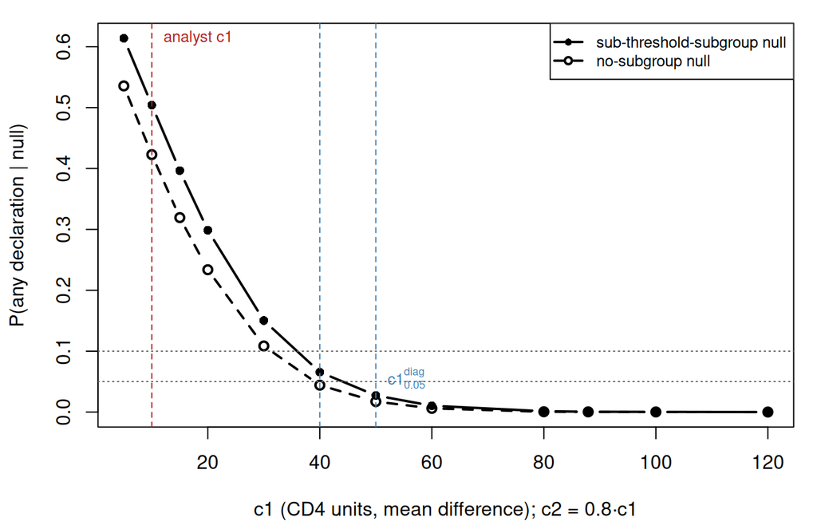

Type-I error of the search under the two nulls along the diagonal c2 = 0.8·c1, at ladder resolution: the sub-threshold-subgroup null (filled) and the no-subgroup null (open, dashed). Guides: the analyst’s c1 = 10, and the sub-threshold c1_05/c1_10 at the 0.05/0.10 lines.

```r
op <- par(mar = c(4.2, 4.2, 1, 1))
plot(tI$c1, tI$det_rate, type = "b", pch = 16, lwd = 2,
     ylim = range(0, tI$det_rate, tIh$det_rate),
     xlab = "c1 (CD4 units, mean difference); c2 = 0.8·c1",
     ylab = "P(any declaration | null)")
lines(tIh$c1, tIh$det_rate, type = "b", pch = 1, lty = 2, lwd = 2)
abline(h = c(0.05, 0.10), lty = 3, col = "grey40")
abline(v = 10, lty = 2, col = "firebrick")
abline(v = c(c1_05_diag, c1_10_diag), lty = 2, col = "steelblue")
text(10, max(tI$det_rate), "analyst c1", pos = 4, cex = 0.8, col = "firebrick")
text(c1_05_diag, 0.05, expression(c1[0.05]^diag), pos = 4, cex = 0.8,
     col = "steelblue")
legend("topright", legend = c("sub-threshold-subgroup null",
                              "no-subgroup null"),
       pch = c(16, 1), lty = c(1, 2), lwd = 2, cex = 0.8, bg = "white")
```

```r
par(op)
```

### 0.7.2 7.2 The effect ladder

Per rung: the declaration rate at the analyst’s diagonal gate (c1 = 10, c2 = 8), the power at the diagonal fixed-type-I thresholds, and the calibration columns P(T ≥ T̂<sub>obs</sub> | q) — read at c1 = T̂<sub>obs</sub> with the analyst’s operating consistency floor c2 = 8 and, alongside, the archived comparator c2 = 5. c2 sets candidate *eligibility*, and the calibration interrogates the analysis as actually conducted, so it is read at the analyst’s own consistency floor while type-I and power are read on the policy diagonal.

```r
lad <- do.call(rbind, lapply(q_rungs, function(qv) {
  d  <- diag_of(qv)
  dq <- ocp[ocp$q == qv, ]
  data.frame(
    q      = qv,
    det10  = at(d, 10, params$c2_ratio * 10)$det_rate,
    det10s = at(d, 10, params$c2_ratio * 10)$det_rate_se,
    p05    = at(d, c1_05_diag, params$c2_ratio * c1_05_diag)$det_rate,
    p05s   = at(d, c1_05_diag, params$c2_ratio * c1_05_diag)$det_rate_se,
    p10    = at(d, c1_10_diag, params$c2_ratio * c1_10_diag)$det_rate,
    p10s   = at(d, c1_10_diag, params$c2_ratio * c1_10_diag)$det_rate_se,
    pT     = at(dq, T_obs, params$c2_ratio * 10)$det_rate,
    pTs    = at(dq, T_obs, params$c2_ratio * 10)$det_rate_se,
    pT5    = at(dq, T_obs, 5)$det_rate,
    pT5s   = at(dq, T_obs, 5)$det_rate_se)
}))

# gate: power columns monotone in q within 2 MC SEs
mono_ok <- function(p, s) all(diff(p) >= -2 * sqrt(s[-1]^2 + s[-length(s)]^2))
stopifnot(mono_ok(lad$det10, lad$det10s), mono_ok(lad$p05, lad$p05s),
          mono_ok(lad$p10, lad$p10s))

gt(data.frame(
  q     = sapply(lad$q, qlab),
  det10 = pm(lad$det10, lad$det10s),
  p05   = pm(lad$p05, lad$p05s),
  p10   = pm(lad$p10, lad$p10s),
  pT    = pm(lad$pT, lad$pTs),
  pT5   = pm(lad$pT5, lad$pT5s))) |>
  cols_label(q = "q (planted MD)",
             det10 = paste0("rate at (10, ", fmt(params$c2_ratio * 10, 0), ")"),
             p05 = html(paste0("power at c1<sub>05</sub><sup>diag</sup> = ",
                               fmt0(c1_05_diag))),
             p10 = html(paste0("power at c1<sub>10</sub><sup>diag</sup> = ",
                               fmt0(c1_10_diag))),
             pT = html(paste0("P(T ≥ T̂<sub>obs</sub> | q), c2 = ",
                              fmt(params$c2_ratio * 10, 0))),
             pT5 = html("P(T ≥ T̂<sub>obs</sub> | q), c2 = 5")) |>
  tab_source_note(md(paste0(
    "Rate and power columns on the diagonal c2 = ", fmt(params$c2_ratio, 1),
    "·c1; the calibration columns at c1 = T̂~obs~ with c2 at the analyst's ",
    "operating floor (", fmt(params$c2_ratio * 10, 0), ") and the archived ",
    "comparator (5); one ", format(params$draws, big.mark = ","),
    "-draw set per rung; ± is the Monte-Carlo SE.")))
```

| q (planted MD) | rate at (10, 8) | power at c1<sub>05</sub><sup>diag</sup> = 50 | power at c1<sub>10</sub><sup>diag</sup> = 40 | P(T ≥ T̂<sub>obs</sub> \| q), c2 = 8 | P(T ≥ T̂<sub>obs</sub> \| q), c2 = 5 |
| --- | --- | --- | --- | --- | --- |
| 0.01 | 0.5042 ± 0.0035 | 0.0272 ± 0.0012 | 0.0657 ± 0.0018 | 0.0382 ± 0.0014 | 0.0382 ± 0.0014 |
| 5.0 | 0.5233 ± 0.0035 | 0.0320 ± 0.0012 | 0.0738 ± 0.0018 | 0.0439 ± 0.0014 | 0.0439 ± 0.0014 |
| 10.0 | 0.5446 ± 0.0035 | 0.0369 ± 0.0013 | 0.0846 ± 0.0020 | 0.0515 ± 0.0016 | 0.0515 ± 0.0016 |
| 15.0 | 0.5696 ± 0.0035 | 0.0446 ± 0.0015 | 0.0970 ± 0.0021 | 0.0614 ± 0.0017 | 0.0614 ± 0.0017 |
| 20.0 | 0.5967 ± 0.0035 | 0.0547 ± 0.0016 | 0.1134 ± 0.0022 | 0.0735 ± 0.0018 | 0.0735 ± 0.0018 |
| 40.0 | 0.7166 ± 0.0032 | 0.1230 ± 0.0023 | 0.2132 ± 0.0029 | 0.1549 ± 0.0026 | 0.1549 ± 0.0026 |
| 60.0 | 0.8369 ± 0.0026 | 0.2680 ± 0.0031 | 0.3863 ± 0.0034 | 0.3169 ± 0.0033 | 0.3169 ± 0.0033 |
| 87.92 | 0.9522 ± 0.0015 | 0.5766 ± 0.0035 | 0.6926 ± 0.0033 | 0.6305 ± 0.0034 | 0.6305 ± 0.0034 |

Rate and power columns on the diagonal c2 = 0.8·c1; the calibration columns at c1 = T̂<sub>obs</sub> with c2 at the analyst’s operating floor (8) and the archived comparator (5); one 20,000-draw set per rung; ± is the Monte-Carlo SE.

### 0.7.3 7.3 What is declared at (c1 = 10, c2 = 8)

Conditional on declaring at the analyst’s diagonal gate: the expected size of the declared subgroup, its expected overlap quality against Q, the expected true oriented effect on the declared rule, the naive selection bias, and the selection mass on rules whose true mean is below c1.

```r
dec <- do.call(rbind, lapply(q_rungs, function(qv)
  at(ocp[ocp$q == qv, ], 10, params$c2_ratio * 10)))

# gate: the sub-threshold row's declared rules carry an oriented-NEGATIVE
# expected true effect (the honest false-positive reading)
stopifnot(dec$EbetaH[1] < 0)

gt(data.frame(
  q     = sapply(dec$q, qlab),
  EnH   = fmt(dec$EnH, 1),
  Eppv  = fmt(dec$Eppv, 3),
  Esens = fmt(dec$Esens, 3),
  Espec = fmt(dec$Espec, 3),
  Ebeta = fmt(dec$EbetaH, 2),
  naive = fmt(dec$Enaive_bias, 2),
  mb    = fmt(dec$mass_below, 3))) |>
  cols_label(q = "q", EnH = md("E\\|Ĥ\\|"), Eppv = "E[PPV]",
             Esens = "E[sens]", Espec = "E[spec]", Ebeta = md("E[β(Ĥ)]"),
             naive = "naive bias", mb = "mass below c1") |>
  tab_source_note(md(paste0(
    "All conditional on declaration at (c1 = 10, c2 = ",
    fmt(params$c2_ratio * 10, 0), "). The archived companion carries ",
    "delta-method MC SEs for these functionals at 2e5 draws.")))
```

| q | E\|Ĥ\| | E[PPV] | E[sens] | E[spec] | E[β(Ĥ)] | naive bias | mass below c1 |
| --- | --- | --- | --- | --- | --- | --- | --- |
| 0.01 | 76.1 | 0.174 | 0.181 | 0.937 | -22.29 | 91.76 | 1.000 |
| 5.0 | 75.6 | 0.201 | 0.208 | 0.939 | -20.54 | 90.55 | 1.000 |
| 10.0 | 75.2 | 0.232 | 0.237 | 0.942 | -18.41 | 89.04 | 1.000 |
| 15.0 | 74.7 | 0.267 | 0.271 | 0.945 | -15.77 | 87.09 | 0.909 |
| 20.0 | 74.1 | 0.306 | 0.308 | 0.948 | -12.62 | 84.80 | 0.846 |
| 40.0 | 71.9 | 0.464 | 0.459 | 0.960 | 4.10 | 73.00 | 0.513 |
| 60.0 | 69.5 | 0.632 | 0.615 | 0.973 | 27.99 | 56.93 | 0.320 |
| 87.92 | 67.2 | 0.811 | 0.779 | 0.987 | 66.16 | 35.03 | 0.117 |

All conditional on declaration at (c1 = 10, c2 = 8). The archived companion carries delta-method MC SEs for these functionals at 2e5 draws.

The sub-threshold row is the honest false-positive reading: when the sub-threshold-subgroup null declares (rate 0.5042), the declared rule’s expected true oriented effect is -22.29 — a *benefit*, not a harm, pulled up from the pure background -26.98 only by the selection mass on partially-Q-overlapping rules (E[PPV] = 0.174).

## 0.8 8. The c2 = 5 comparator

The analyst’s original gate held c2 fixed at 5 against c1 = 10 — and against every other c1, which is the configuration the archived deep run evaluates. A fixed c2 = 5 against c1 = 50 makes no sense as practice — the consistency floor should grow with the claim being screened — so the fixed row is kept here only as the liberal comparator reconciling with the archived run.

```r
cmp <- do.call(rbind, lapply(q_rungs, function(qv)
  at(ocp[ocp$q == qv, ], 10, 5)))
gt(data.frame(
  q     = sapply(cmp$q, qlab),
  det   = pm(cmp$det_rate, cmp$det_rate_se),
  EnH   = fmt(cmp$EnH, 1),
  Eppv  = fmt(cmp$Eppv, 3),
  Ebeta = fmt(cmp$EbetaH, 2))) |>
  cols_label(q = "q", det = "rate at (10, 5)", EnH = md("E\\|Ĥ\\|"),
             Eppv = "E[PPV]", Ebeta = md("E[β(Ĥ)]")) |>
  tab_source_note("The analyst's original fixed-c2 gate, at this document's draw count.")
```

| q | rate at (10, 5) | E\|Ĥ\| | E[PPV] | E[β(Ĥ)] |
| --- | --- | --- | --- | --- |
| 0.01 | 0.5884 ± 0.0035 | 76.1 | 0.171 | -22.38 |
| 5.0 | 0.6070 ± 0.0035 | 75.6 | 0.197 | -20.68 |
| 10.0 | 0.6273 ± 0.0034 | 75.1 | 0.226 | -18.61 |
| 15.0 | 0.6507 ± 0.0034 | 74.8 | 0.260 | -16.06 |
| 20.0 | 0.6764 ± 0.0033 | 74.2 | 0.296 | -13.06 |
| 40.0 | 0.7792 ± 0.0029 | 71.8 | 0.453 | 3.37 |
| 60.0 | 0.8808 ± 0.0023 | 69.5 | 0.621 | 27.00 |
| 87.92 | 0.9663 ± 0.0013 | 67.0 | 0.807 | 65.80 |

The analyst's original fixed-c2 gate, at this document's draw count.

The sub-threshold-null rate at (10, 5) here is 0.5884 ± 0.0035, against the archived deep run’s 0.5850 ± 0.0011 at 2e5 draws — the two agree to Monte-Carlo precision, and remaining differences across the tables are MC precision and ladder-resolution effects, not configuration.

## 0.9 9. The type-I surface

The false-declaration rate under the sub-threshold-subgroup null over the full (c1, c2) crossing, with the fixed c2 = 5 row and the c2 = 0.8·c1 diagonal marked.

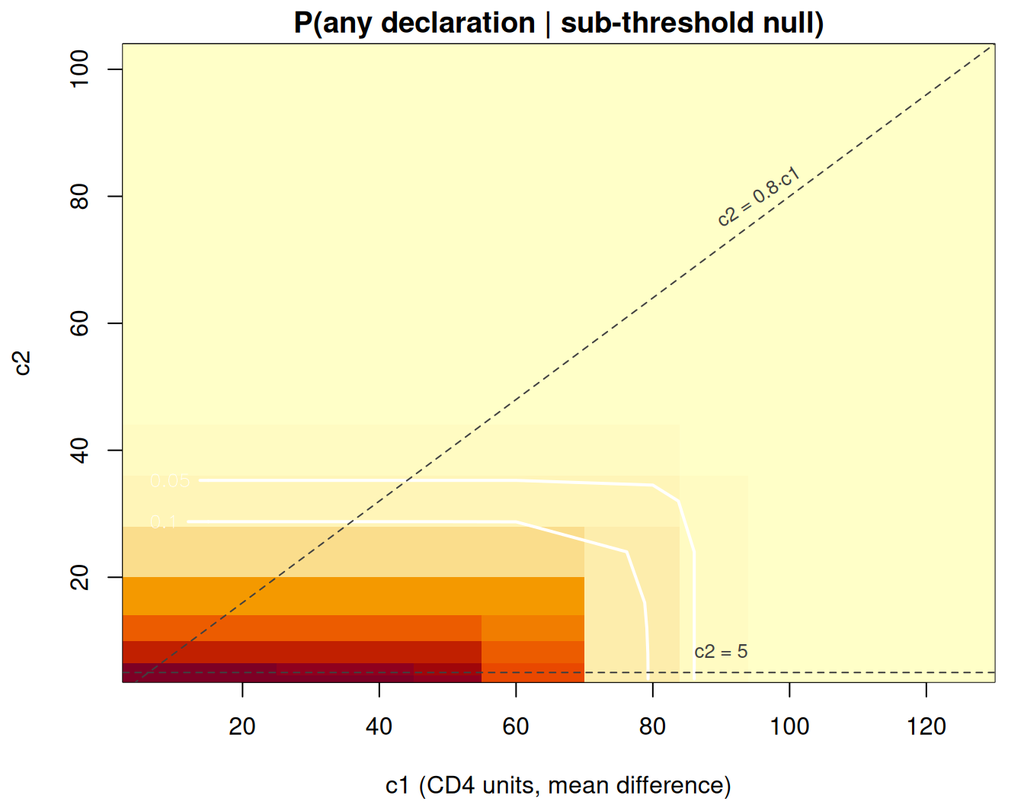

Type-I error of the search under the sub-threshold-subgroup null over the (c1, c2) crossing. White contour lines at 0.05 and 0.10; dashed lines mark the fixed c2 = 5 comparator row and the c2 = 0.8·c1 diagonal.

```r
z <- ocp[ocp$q == q_rungs[1], ]
zm <- matrix(NA_real_, length(c1_ladder), length(c2_vec))
for (i in seq_along(c1_ladder)) for (j in seq_along(c2_vec))
  zm[i, j] <- at(z, c1_ladder[i], c2_vec[j])$det_rate
op <- par(mar = c(4.2, 4.2, 1.5, 1))
image(c1_ladder, c2_vec, zm, col = hcl.colors(24, "YlOrRd", rev = TRUE),
      xlab = "c1 (CD4 units, mean difference)", ylab = "c2",
      main = "P(any declaration | sub-threshold null)")
contour(c1_ladder, c2_vec, zm, levels = c(0.05, 0.10), add = TRUE,
        col = "white", lwd = 2, labcex = 0.8)
abline(h = 5, lty = 2, col = "grey25")
abline(a = 0, b = params$c2_ratio, lty = 2, col = "grey25")
text(max(c1_ladder) * 0.75, 5, "c2 = 5", pos = 3, cex = 0.8, col = "grey25")
text(max(c1_ladder) * 0.8, params$c2_ratio * max(c1_ladder) * 0.8,
     "c2 = 0.8·c1", pos = 3, srt = 33, cex = 0.8, col = "grey25")
```

```r
par(op)
```

```r
tI5 <- do.call(rbind, lapply(c1_ladder, function(c1v) at(z, c1v, 5)))
c1_05_fix <- suppressWarnings(min(tI5$c1[tI5$det_rate <= 0.05]))
```

The picture is the point of the scaled policy: along the diagonal the consistency screen binds (for noisy candidates 0.8·c1 + z<sub>p</sub>·se<sub>g</sub> overtakes c1), so 5% type-I control arrives at c1<sub>05</sub><sup>diag</sup> = 50 on the diagonal versus 87 on the fixed c2 = 5 row at the same ladder resolution.

## 0.10 10. Turning the true-subgroup knob

The primary evaluation plants Ĥ itself. This section turns the knob of section 3: the same analysis, the same family, the same thresholds, scored against each variant’s own Q — power at the diagonal fixed-type-I threshold for the common rungs (q = 20, 40, T̂<sub>obs</sub>), the declared rule’s overlap quality at the analyst’s (10, 8) on the observed-statistic rung, and the calibration crossings, read as in section 7.2 at c1 = T̂<sub>obs</sub> with the analyst’s operating c2 = 8 and the archived comparator c2 = 5 alongside. Each variant’s calibration curve is anchored by its own sub-threshold null rung (section 6).

```r
cal <- lapply(names(Q_variants), function(v) {
  qs <- if (v == "primary") q_rungs else q_shared
  read_pT <- function(c2v) sapply(qs, function(qv) {
    d <- oc[oc$variant == v, ]   # every rung is the variant's own, incl. 0.01
    at(d[d$q == qv, ], T_obs, c2v)$det_rate
  })
  list(qs = qs, pT = read_pT(params$c2_ratio * 10), pT5 = read_pT(5))
})
names(cal) <- names(Q_variants)

cross <- function(qs, pT, lev) {
  i <- which(pT >= lev)[1]
  if (is.na(i)) NA_real_
  else if (i == 1) qs[1]
  else qs[i - 1] + (lev - pT[i - 1]) * (qs[i] - qs[i - 1]) / (pT[i] - pT[i - 1])
}
knob <- do.call(rbind, lapply(names(Q_variants), function(v) {
  d   <- oc[oc$variant == v, ]
  pow <- sapply(c(20, 40, T_obs), function(qv)
    at(d[d$q == qv, ], c1_05_diag, params$c2_ratio * c1_05_diag)$det_rate)
  top <- at(d[abs(d$q - T_obs) < 1e-9, ], 10, params$c2_ratio * 10)
  data.frame(variant = v,
             def   = sprintf("age ≤ %s & cd40 > %s",
                             format(Q_variants[[v]]$age),
                             format(Q_variants[[v]]$cd40$value)),
             P     = prev[v], ratio = prev[v] / prev["primary"],
             p20   = pow[1], p40 = pow[2], ptop = pow[3],
             ppv   = top$Eppv, sens = top$Esens,
             q05   = cross(cal[[v]]$qs, cal[[v]]$pT, 0.05),
             q50   = cross(cal[[v]]$qs, cal[[v]]$pT, 0.50),
             q05c  = cross(cal[[v]]$qs, cal[[v]]$pT5, 0.05),
             q50c  = cross(cal[[v]]$qs, cal[[v]]$pT5, 0.50))
}))

# report, not a gate: with rungs near the 0.05 level and MC SE ~ 0.004 a
# calibration column can be non-monotone in q by chance, which would make
# cross()'s first-crossing read noisy — check within 2 MC SEs and print
cal_se <- lapply(names(Q_variants), function(v) {
  qs <- if (v == "primary") q_rungs else q_shared
  sapply(qs, function(qv) {
    d <- oc[oc$variant == v, ]
    at(d[d$q == qv, ], T_obs, params$c2_ratio * 10)$det_rate_se
  })
})
names(cal_se) <- names(Q_variants)
mono_cal <- sapply(names(Q_variants), function(v)
  mono_ok(cal[[v]]$pT, cal_se[[v]]))
cat("calibration column non-decreasing in q within 2 MC SEs:\n")
```

```
calibration column non-decreasing in q within 2 MC SEs:
```

```r
print(mono_cal)
```

```
primary   wider   broad
   TRUE    TRUE    TRUE
```

```r
qfmt <- function(x) ifelse(is.na(x), "beyond the ladder",
                    ifelse(x <= q_rungs[1], paste0("≤ ", qlab(q_rungs[1])),
                           fmt(x, 1)))
gt(data.frame(
  v    = knob$variant,
  def  = knob$def,
  P    = paste0(fmt(knob$P, 4), " (", fmt(knob$ratio, 2), "×)"),
  p20  = fmt(knob$p20, 4), p40 = fmt(knob$p40, 4), ptop = fmt(knob$ptop, 4),
  ppv  = fmt(knob$ppv, 3), sens = fmt(knob$sens, 3),
  q05  = qfmt(knob$q05),
  q05c = qfmt(knob$q05c),
  q50  = qfmt(knob$q50),
  q50c = qfmt(knob$q50c))) |>
  cols_label(v = "Q variant", def = "definition", P = "P(Q)",
             p20 = "power, q = 20", p40 = "power, q = 40",
             ptop = html("power, q = T̂<sub>obs</sub>"),
             ppv = "E[PPV]", sens = "E[sens]",
             q05 = paste0("q at 0.05 (c2 = ", fmt(params$c2_ratio * 10, 0), ")"),
             q05c = "q at 0.05 (c2 = 5)",
             q50 = paste0("q at 0.5 (c2 = ", fmt(params$c2_ratio * 10, 0), ")"),
             q50c = "q at 0.5 (c2 = 5)") |>
  tab_source_note(md(paste0(
    "Power columns at the diagonal (c1 = ", fmt0(c1_05_diag), ", c2 = ",
    fmt(params$c2_ratio * c1_05_diag, 1), "); E[PPV]/E[sens] scored against ",
    "the variant's own Q, conditional on declaration at (10, ",
    fmt(params$c2_ratio * 10, 0), ") on the q = T̂~obs~ rung; the last four ",
    "columns are the q where P(T ≥ T̂~obs~ | q, Q), read at c1 = T̂~obs~ ",
    "and the stated c2, crosses 0.05 / 0.5, interpolated linearly at ladder ",
    "resolution with each variant's own sub-threshold null point.")))
```

| Q variant | definition | P(Q) | power, q = 20 | power, q = 40 | power, q = T̂<sub>obs</sub> | E[PPV] | E[sens] | q at 0.05 (c2 = 8) | q at 0.05 (c2 = 5) | q at 0.5 (c2 = 8) | q at 0.5 (c2 = 5) |
| --- | --- | --- | --- | --- | --- | --- | --- | --- | --- | --- | --- |
| primary | age ≤ 37 & cd40 > 507 | 0.0634 (1.00×) | 0.0547 | 0.1230 | 0.5766 | 0.811 | 0.779 | 9.0 | 9.0 | 76.3 | 76.3 |
| wider | age ≤ 39 & cd40 > 449 | 0.1240 (1.96×) | 0.0932 | 0.2351 | 0.8556 | 0.861 | 0.499 | 0.9 | 0.9 | 60.1 | 60.1 |
| broad | age ≤ 39 & cd40 > 412 | 0.1906 (3.01×) | 0.1216 | 0.3244 | 0.9512 | 0.870 | 0.343 | ≤ 0.01 | ≤ 0.01 | 54.0 | 54.0 |

Power columns at the diagonal (c1 = 50, c2 = 40.0); E[PPV]/E[sens] scored against the variant’s own Q, conditional on declaration at (10, 8) on the q = T̂<sub>obs</sub> rung; the last four columns are the q where P(T ≥ T̂<sub>obs</sub> | q, Q), read at c1 = T̂<sub>obs</sub> and the stated c2, crosses 0.05 / 0.5, interpolated linearly at ladder resolution with each variant’s own sub-threshold null point.

Each variant’s calibration column is non-decreasing in q within 2 MC SEs, so the crossing reads are clean.

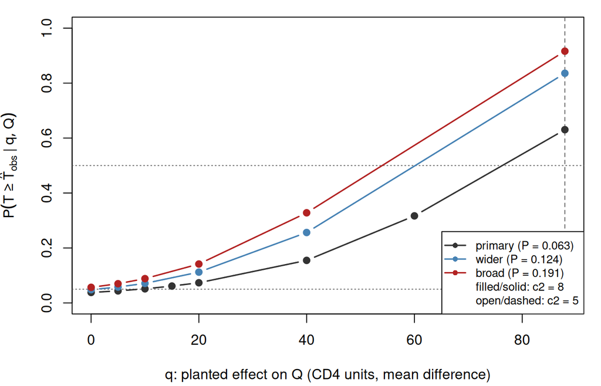

Calibration curves P(T ≥ T̂_obs | q, Q) for the three Q-variants at the analyst’s operating c2 = 8 (filled, solid) and the archived comparator c2 = 5 (open, dashed), each anchored by its own sub-threshold null point. Dotted guides at 0.05 and 0.5; the vertical dashed line marks q = T̂_obs.

```r
cols3 <- c(primary = "grey20", wider = "steelblue", broad = "firebrick")
op <- par(mar = c(4.2, 4.2, 1, 1))
plot(NA, xlim = c(0, max(q_rungs)), ylim = c(0, 1),
     xlab = "q: planted effect on Q (CD4 units, mean difference)",
     ylab = expression(P(T >= hat(T)[obs] ~ "|" ~ q, Q)))
abline(h = c(0.05, 0.5), lty = 3, col = "grey40")
abline(v = T_obs, lty = 2, col = "grey40")
for (v in names(cal)) {
  lines(cal[[v]]$qs, cal[[v]]$pT, type = "b", pch = 16, lwd = 1.6,
        col = cols3[v])
  lines(cal[[v]]$qs, cal[[v]]$pT5, type = "b", pch = 1, lty = 2, lwd = 1.2,
        col = cols3[v])
}
legend("bottomright",
       legend = c(sprintf("%s (P = %.3f)", names(cal), prev),
                  paste0("filled/solid: c2 = ", fmt(params$c2_ratio * 10, 0)),
                  "open/dashed: c2 = 5"),
       col = c(cols3, "grey40", "grey40"), lwd = c(rep(1.6, 3), NA, NA),
       pch = c(rep(16, 3), NA, NA), cex = 0.8, bg = "white")
```

```r
par(op)
```

The reading this section exists for: **the observed statistic constrains a trade between breadth and severity.** At the analyst’s operating gate (c2 = 8), under the primary Q the calibration curve crosses 0.5 at q ≈ 76.3 CD4 units of planted harm; under the 2.0×-prevalence wider Q it crosses at q ≈ 60.1, and under the 3.0×-prevalence broad Q at q ≈ 54.0 — a narrow Q needs a large planted harm to make T̂<sub>obs</sub> = 87.9 unsurprising, a broad Q a smaller one. The c2 = 5 comparator columns should sit close to the c2 = 8 columns, and the archived deep run (fixed c2 = 5, 2×10<sup>5</sup> draws) put the primary 0.05 crossing at q ≈ 7.5. “What harm is consistent with what we saw” has no single answer without fixing who is harmed; the table says what each choice implies.

## 0.11 11. Reading and limitations

- **Three different questions.** The declaration event (sections 7.1–7.2), the declared rule’s quality and magnitude (7.3), and the calibration columns for the observed statistic (7.2, last two columns) answer different questions; none is a posterior, and the calibration columns are consonance statements inside the anchored model only. The c2 policy applies to the first two — type-I and power are threshold-policy quantities read on the diagonal — and not to the calibration read-off, which is taken at the analyst’s operating consistency floor.
- **Two nulls.** The no-subgroup null (section 6, by substitution) and the sub-threshold-subgroup null (the q = 0.01 rung) bracket the null question; the generator’s `k_inter = 0` route to the first is unusable under the 0.3.2 orientation (every oriented mean flips to +26.98), a recorded limitation of the orientation at a homogeneous truth, documented here in prose and not patched.
- **The mixture stylization.** Truths are a two-point effect mixture on the data’s own covariate rows with a GLM baseline surface; real heterogeneity is not two-valued.
- **Q is off the grid.** No family member is identical to Ĥ (nearest purity 0.9969); every “power” number is the power to declare *some* rule.
- **Fixed-family conditioning.** The evaluation conditions on the no-front-end family; the front-ends-on arms of the compare-all document search a data-dependent family, a different estimand. The cut locations are quantile-derived and held at their population values.
- **The E|Ĥ| machinery offset.** In the verification fixtures the wrapper’s expected declared-subgroup size ran about two subjects from the measured search’s; assume that order of offset here.
- **Precision.** All rates carry MC SE ≈ √(p(1−p)/draws) ≈ 0.004 at the default 20,000 draws; the archived companion holds the fixed-c2 analysis at 2e5 draws.

## 0.12 12. Interpretation: what the analysis may claim

The analysis found **Ĥ = `{age <= 37} & !{cd40 <= 507}`** — n(Ĥ) = 66 of 1083, fitted mean difference T̂<sub>obs</sub> = 87.9 CD4 units, consistency 0.95 — against an unadjusted ITT mean difference of -27.6 CD4 units (SE 7.9), a benefit on average. (The covariate-adjusted GLM coefficient `beta_treat` = -27.0, which the generator anchors to, is a related but distinct quantity; the two are not conflated here.) The sections above ask what the procedure as configured does under truths anchored to this data; this section says what may therefore be claimed. The caveats governing all of it are section 11’s and are not repeated here.

### 0.12.1 12.1 The declaration event is close to uninformative

At (c1 = 10, c2 = 8) the search declares *some* harm subgroup with probability 0.423 under the no-subgroup null and 0.504 under the sub-threshold-subgroup null; at the fixed (10, 5) gate the latter is 0.588. Two consequences. First, “ForestSearch identified a subgroup” carries almost no evidential weight at this configuration. Second, because the two nulls differ by only 0.081, the rate is driven by multiplicity over M = 4508 correlated candidates and a liberal threshold, not by a lurking weak subgroup. The thresholds are clinical-relevance floors, not error controls.

### 0.12.2 12.2 The observed magnitude — a range, not a p-value

```r
tail_tab <- data.frame(
  truth = c("no subgroup (homogeneous)",
            "Q = H-hat (primary), zero effect",
            "Q = wider, zero effect",
            "Q = broad, zero effect"),
  rate  = c(hom_at_Tobs$det_rate, unname(det0)),
  se    = c(hom_at_Tobs$det_rate_se,
            sapply(names(Q_variants), function(v) {
              d <- oc[oc$variant == v, ]
              at(d[d$q == q_rungs[1], ], T_obs,
                 params$c2_ratio * 10)$det_rate_se
            })))
gt(data.frame(truth = tail_tab$truth, p = pm(tail_tab$rate, tail_tab$se))) |>
  cols_label(truth = "truth", p = html("P(T ≥ T̂<sub>obs</sub>)")) |>
  tab_source_note(md(paste0(
    "Read at (c1 = T̂~obs~, c2 = ", fmt(params$c2_ratio * 10, 0),
    ") as in section 7.2; ± is the Monte-Carlo SE.")))
```

| truth | P(T ≥ T̂<sub>obs</sub>) |
| --- | --- |
| no subgroup (homogeneous) | 0.0237 ± 0.0011 |
| Q = H-hat (primary), zero effect | 0.0382 ± 0.0014 |
| Q = wider, zero effect | 0.0483 ± 0.0015 |
| Q = broad, zero effect | 0.0568 ± 0.0016 |

Read at (c1 = T̂<sub>obs</sub>, c2 = 8) as in section 7.2; ± is the Monte-Carlo SE.

This is the selection-honest tail probability of the observed statistic, computed against the distribution of the search’s own maximum, so multiplicity is already inside it. The answer is a **range** — from 0.0237 with no subgroup at all to 0.0568 under the broad reading — that depends on how broad the truly affected population may be, and under the broad reading the observation is not surprising even at zero harm. As an external cross-check (computed in the archived `analysis_actg175_continuous_oc_evaluation` deep run, not here), the primary row’s value at 2×10<sup>5</sup> draws was 0.041. The observed magnitude is suggestive, not decisive, under every null in the family.

### 0.12.3 12.3 The magnitude of the harm is weakly identified

The 0.05 consonance crossings of section 10 put the smallest planted harm consistent with T̂<sub>obs</sub> at q ≈ 9.0 CD4 units if the harmed population is exactly Ĥ, but q ≈ 0.9 under the wider reading and ≤ 0.01 under the broad one — collapsing toward the first rung — against the naive T̂<sub>obs</sub> = 87.9 and the analysis’s own floor c1 = 10. If the harmed population is not exactly the rule the search returned, the data are consistent with arbitrarily small harm. **Do not quote T̂<sub>obs</sub> as an effect size**: the de-biased (multiplier-resampling / bootstrap) estimates are the estimation-side response, and this curve is the design-side statement of why they are needed.

### 0.12.4 12.4 What error control costs

Holding the family-wise false-declaration rate at 0.05 requires c1 = 50 on the scaled diagonal (c1 = 40 against the no-subgroup null alone, and 87 on the fixed c2 = 5 row) — thresholds far above the clinical floor — and at that gate power is 0.58 even at the observed-statistic rung and lower at every smaller planted effect (section 7.2). No configuration on this ladder is a test: strict control costs most of the power at every planted effect examined, so the finding is hypothesis-generating and needs prespecified confirmation — which this same machinery can size.

### 0.12.5 12.5 Breadth versus severity

For T̂<sub>obs</sub> to be *typical* (the 0.5 crossing), a subgroup exactly Ĥ must be harmed by q ≈ 76.3 CD4 units, the wider population by q ≈ 60.1, the broad one by q ≈ 54.0; meanwhile top-rung power rises 0.58 → 0.95 across the variants as the declared rule’s sensitivity to the true Q falls 0.78 → 0.34. A narrow true subgroup must be severely harmed to make T̂<sub>obs</sub> typical; a broad one need only be mildly harmed — section 10’s table carries the full statement.

### 0.12.6 12.6 A draft results paragraph

*A draft for the analyst to adapt — not a conclusion of this document:*

> ForestSearch, configured with clinical-relevance floors rather than error controls, identified Ĥ = {age <= 37} & !{cd40 <= 507} (n = 66 of 1083) with fitted mean difference 87.9 CD4 units; since the procedure declares some subgroup with probability 0.42–0.50 under nulls anchored to these data, the identification is hypothesis-generating. The observed statistic’s selection-honest tail probability ranges from 0.0237 (no subgroup) to 0.057 (a broad mildly-affected population), and the harm magnitude consistent with it at the 0.05 consonance level ranges from essentially zero if the affected population is the broad variant to 9.0 CD4 units if it is Ĥ itself, so the fitted magnitude should not be quoted as an effect estimate. A prespecified confirmation in independent data — sized with the same operating-characteristic machinery — is required before any clinical claim.

Three external facts cited above and in section 11, named as external: the archived deep run’s calibration values (`analysis_actg175_continuous_oc_evaluation`), and the ~2-subject E|Ĥ| machinery offset (the verification fixtures, section 11); the archived `se_direct` sensitivity’s ≤ 1.4-point movement of the calibration column (same archived document) bounds the se-model choice.

```r
cat(sprintf("document compute wall-clock so far: %.1f min\n",
            (proc.time()[["elapsed"]] - t_doc) / 60))
```

```
document compute wall-clock so far: 53.3 min
```

```r
# TASK_actg175_continuous_intervals_2026-09-07: the OC loop needs about 11 GB per worker
cat(sprintf("rendered with n_workers = %d (the OC loop needs about 11 GB per worker: one fs_oc_grid() job on %s draws x M = %d in one block)\n",
            params$n_workers, format(params$draws, big.mark = ","), fam$M))
```

```
rendered with n_workers = 14 (the OC loop needs about 11 GB per worker: one fs_oc_grid() job on 20,000 draws x M = 4508 in one block)
```

# 1 Reproducibility payload

```
Wrote payload to: /home/larryleon/Documents/GitHub/forestsearch/quarto/applications/actg175/_payloads/analysis_actg175_continuous_oc_intervals/analysis_actg175_continuous_oc_intervals_payload.rds
```